# KDSC S4 Bootcamp

#### 5.4.4 Boxplots

**Boxplots** give a compact summary of a distribution’s center, spread, and outliers.

- The box spans from the first quartile (Q1) to the third quartile (Q3), containing the middle 50% of the data.
- The line inside the box marks the median (Q2).
- The whiskers extend from the box to the most extreme values within 1.5 times the interquartile range (IQR) from Q1 or Q3.
- Points beyond the whiskers are considered outliers and are plotted individually as points.

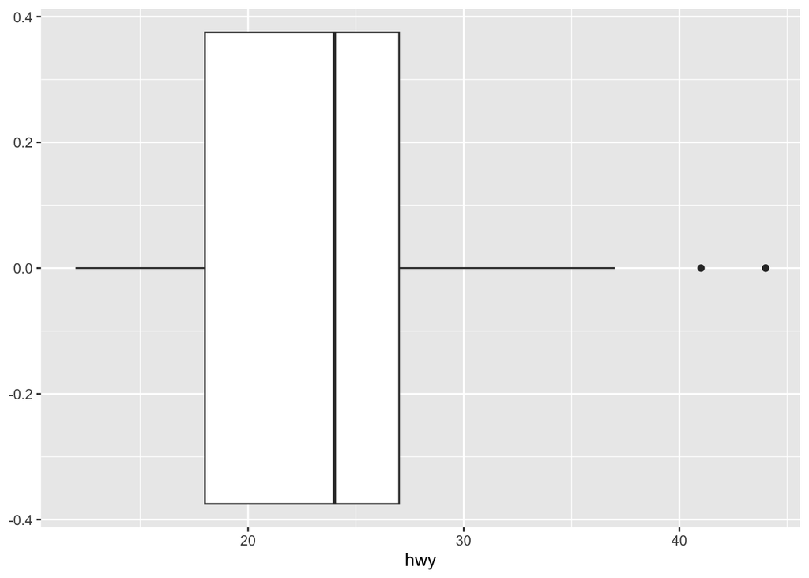

```r
ggplot(data = mpg, mapping = aes(x = hwy)) + geom_boxplot()
```

### 5.5 Visualizing Joint Variability

To examine how two variables vary together, choose a plot that matches their types (numeric–numeric vs. numeric–categorical). The ggplot2 geoms below highlight different relationships and patterns. Note that we now need to specify two aesthetic mappings instead of just one.

#### 5.5.1 Colored density plots (numeric by categorical)

Colored density plots compare the distribution of a numeric variable across categories by overlaying group-wise densities.

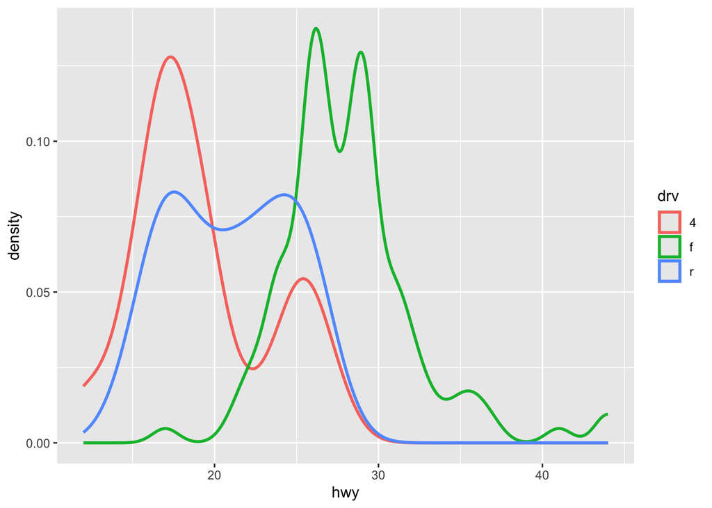

```r
ggplot(data = mpg, mapping = aes(x = hwy, color = drv)) + geom_density(linewidth = 1)
```